# Example report

Kim Dill-McFarland

version March 30, 2018

# Abstract

# Introduction

Saanich Inlet is cool. It is a seasonally anoxic fjord [1]. Other stuff about Sannich…

Information on OTUs vs. ASVs…

Using these data, we investigated how microbial communities differ across depth and oxygen gradients in Saanich Inlet with particular focus on the unclassified domain (*you will have a different taxon than this*). The unclassified domain is of interest because… In addition, we determine if and how different sequence analysis pipelines impact these biological conclusions.

# Methods

We have these data collected in this way for use in this project [1,2]… Sequences were processed using either mothur [3] or QIIME2 [4]…

Analysis was completed in R v3.4.3 [5] using the following packages.

```r
library("tidyverse")
library("phyloseq")
library("magrittr")
```

# Results

This example section is just to give you an idea of some of the analyses that you *could* do with these data. Please do not follow this section exactly! We will only show analyses with the mothur data in these examples and the plots are not perfect (axes labels, etc). *Let your taxon of interest and own biological questions guide the analysis you do!*

### Data cleaning

Data were loaded into R.

```r
load("data/mothur_phyloseq.RData")
```

Samples were rarefied/normalized to 100,000 sequences per sample to facilitate comparisons between samples. A random seed was set to ensure reproducibility.

```r
set.seed(4832)
m.norm = rarefy_even_depth(mothur, sample.size=100000)
```

```
## You set `rngseed` to FALSE. Make sure you've set & recorded
##  the random seed of your session for reproducibility.
## See `?set.seed`
```

```
## ...
```

```
## 614OTUs were removed because they are no longer
## present in any sample after random subsampling
```

```
## ...
```

Rarefied counts were converted to relative abundance percentages.

```r
m.perc = transform_sample_counts(m.norm, function(x) 100 * x/sum(x))
```

### How does microbial community structure change with depth and oxygen concentration?

#### Alpha-diversity

Alpha-diversity and richness were calculated for the total community in R.

```r
# Calculate
m.alpha = estimate_richness(m.norm, measures = c("Chao1", "Shannon"))

# Combine these data with the rest of the geochemical data so that we have 1 data frame to work with in future plots. Note use of the rownames_to_column function which mutates the dataframes to have a new column containing the row names data (because the tidyverse doesn't understand row names).
m.meta.alpha = full_join(rownames_to_column(m.alpha), rownames_to_column(data.frame(m.perc@sam_data)), by = "rowname")

m.meta.alpha
```

| rowname | Chao1 | se.chao1 | Shannon | Depth_m | O2_uM | PO4_uM | SiO2_uM | NO3_uM | NH4_uM | Std_NH4_uM | NO2_uM | Std_NO2_uM | H2S_uM | Std_H2S_uM | Cells.ml | N2O_nM | Std_N2O_nM | CH4_nM | Std_CH4_nM | Temperature_C | Conductivity_mScm_1 | Fluorescence_mgm_3 | OxygenSBE_V | Salinity_PSU | Density_q |
| --- | --- | --- | --- | --- | --- | --- | --- | --- | --- | --- | --- | --- | --- | --- | --- | --- | --- | --- | --- | --- | --- | --- | --- | --- | --- |
| Saanich_010 | 1176.7102 | 23.37910 | 3.945966 | 10 | 216.667 | 0.520 | 20.672 | 1.793 | 0.4080 | 0.0084 | 0.1275 | 0.0088 | 0.0000 | 0.0000 | NAN | 0.849 | 0.114 | 1030.478 | 3.070 | 12.854 | 33.534 | 3.521 | 4.954 | 28.121 | 21.098 |
| Saanich_100 | 1705.9110 | 33.23574 | 4.273747 | 100 | 38.012 | 3.672 | 69.062 | 26.400 | 0.1344 | 0.0092 | 0.0817 | 0.0105 | 0.0000 | 0.0000 | NAN | 18.087 | 1.275 | 3.231 | 0.392 | 8.703 | 32.970 | 0.109 | 0.872 | 30.872 | 23.933 |
| Saanich_120 | 1509.2529 | 30.11850 | 3.937085 | 120 | 32.354 | 4.090 | 64.383 | 21.302 | 0.1782 | 0.0100 | 0.0978 | 0.0018 | 0.0000 | 0.0000 | NAN | 16.304 | 1.085 | 3.463 | 0.519 | 8.796 | 33.188 | 0.197 | 0.742 | 31.007 | 24.026 |
| Saanich_135 | 942.8395 | 15.31532 | 3.203605 | 135 | 20.446 | 4.342 | 70.321 | 15.917 | 0.1296 | 0.0166 | 0.0706 | 0.0018 | 0.0000 | 0.0000 | NAN | 12.909 | 2.577 | 4.815 | 0.658 | 8.882 | 33.345 | 0.108 | 0.469 | 31.088 | 24.076 |
| Saanich_150 | 790.8279 | 20.59633 | 2.349901 | 150 | 0.000 | 4.988 | 70.780 | 5.278 | 2.1754 | 0.0293 | 0.1127 | 0.0018 | 0.0000 | 0.0000 | NAN | 11.815 | 0.000 | 8.323 | 0.000 | 9.002 | 33.526 | 0.181 | 0.089 | 31.164 | 24.118 |
| Saanich_165 | 771.8898 | 22.93917 | 2.350053 | 165 | 0.000 | 5.599 | 62.580 | 0.000 | 4.7095 | 0.2112 | 0.0805 | 0.0053 | 3.5027 | 0.0423 | NAN | 6.310 | 0.732 | 23.831 | 2.291 | 9.041 | 33.597 | 0.132 | 0.069 | 31.197 | 24.138 |
| Saanich_200 | 812.4231 | 20.40070 | 2.465456 | 200 | 0.000 | 6.298 | 66.200 | 0.000 | 7.3582 | 0.2816 | 0.0000 | 0.0000 | 17.9867 | 0.0006 | NAN | 0.000 | 0.000 | 774.034 | 12.745 | 9.117 | 33.727 | 0.236 | 0.063 | 31.248 | 24.167 |

Example plots

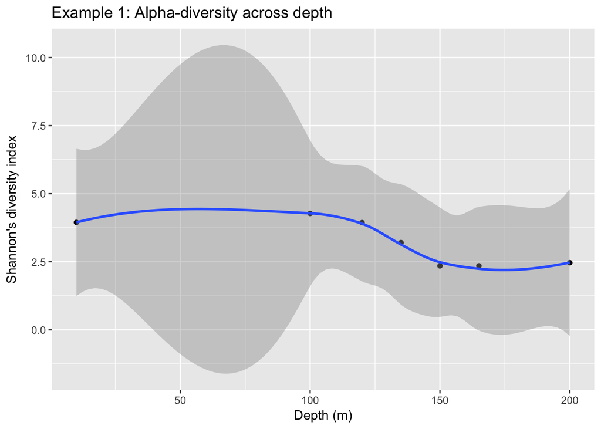

```r
m.meta.alpha %>%

ggplot() +
  geom_point(aes(x=Depth_m, y=Shannon)) +
   geom_smooth(method='auto', aes(x=as.numeric(Depth_m), y=Shannon)) +
  labs(title="Example 1: Alpha-diversity across depth", y="Shannon's diversity index", x="Depth (m)")
```

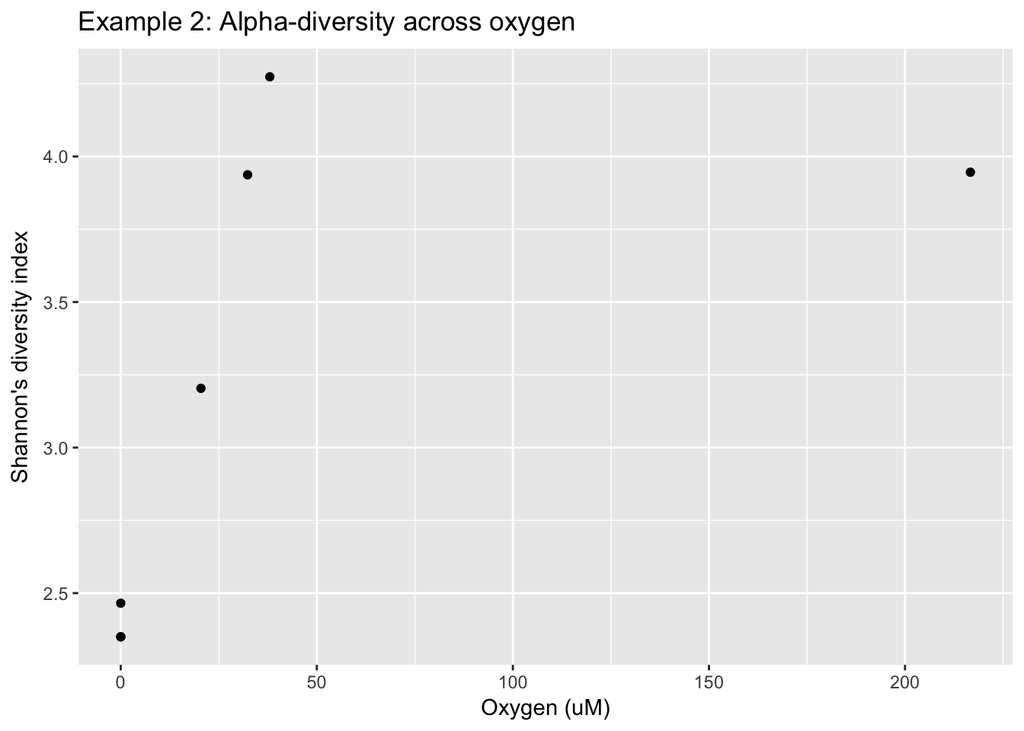

```r
m.meta.alpha %>%

ggplot() +
  geom_point(aes(x=O2_uM, y=Shannon)) +
  labs(title="Example 2: Alpha-diversity across oxygen", y="Shannon's diversity index", x="Oxygen (uM)")
```

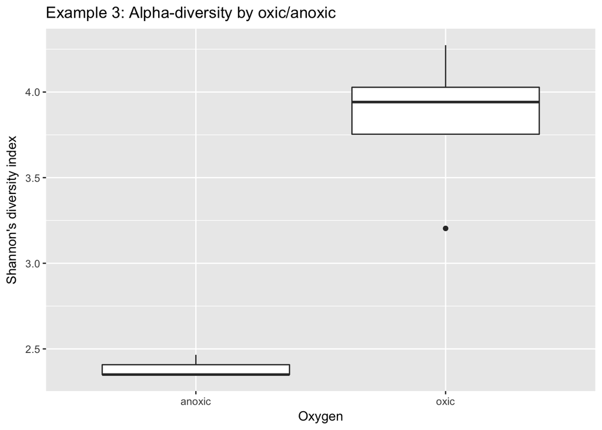

```r
m.meta.alpha %>%
  mutate(O2_group = ifelse(O2_uM == 0, "anoxic", "oxic")) %>%

# Use this in a plot
ggplot() +
  geom_boxplot(aes(x=O2_group, y=Shannon)) +
  labs(title="Example 3: Alpha-diversity by oxic/anoxic", y="Shannon's diversity index", x="Oxygen")
```

#### Taxa presence and abundance

Example plots using `phyloseq` for domain data. You should explore other taxonomy levels.

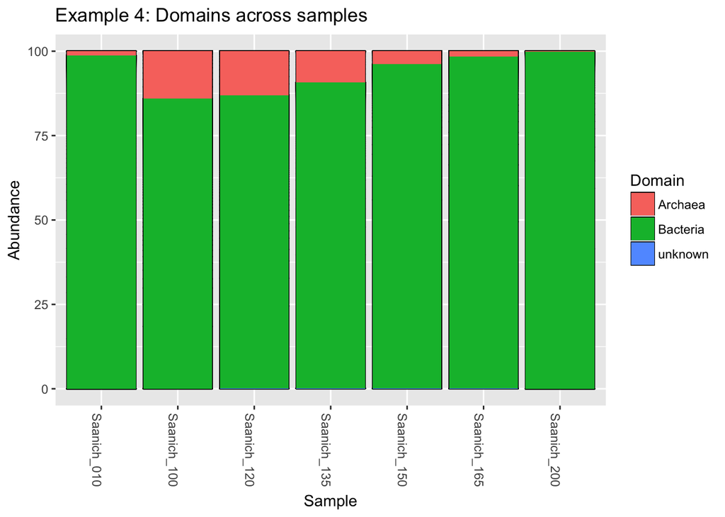

```r
m.perc %>%

plot_bar(fill="Domain") +
  geom_bar(aes(fill=Domain), stat="identity") +
  labs(title="Example 4: Domains across samples")
```

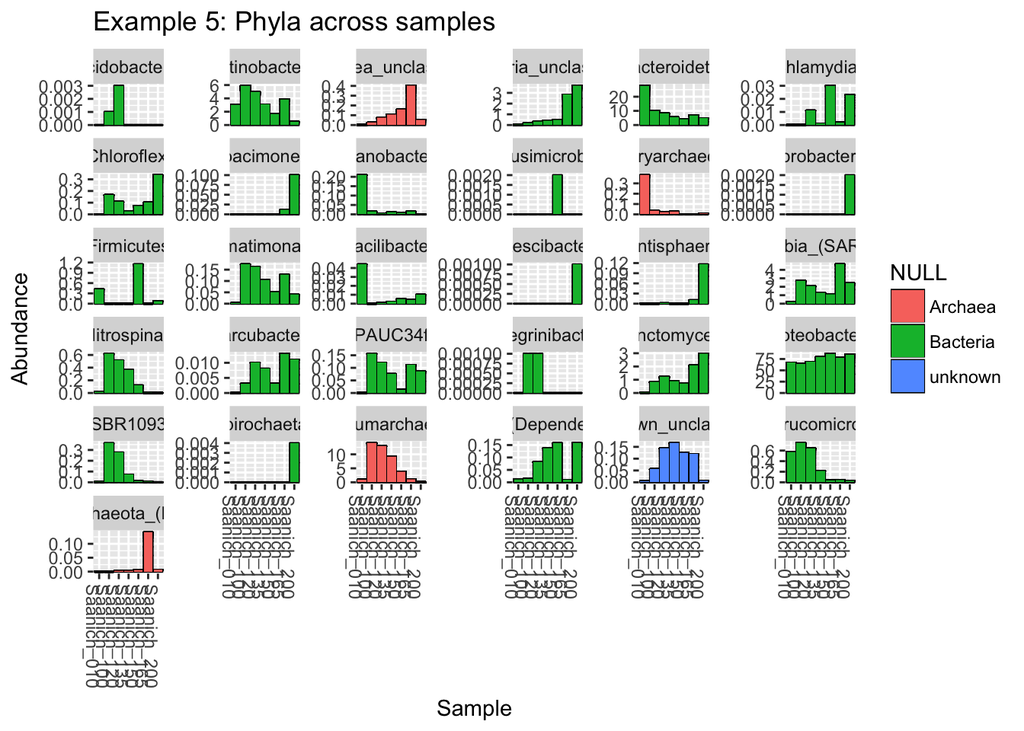

```r
m.perc %>%

plot_bar() +
  geom_bar(aes(fill=Domain), stat="identity") +
  facet_wrap(~Phylum, scales="free_y")+
  labs(title="Example 5: Phyla across samples")
```

Examples outside of `phyloseq`

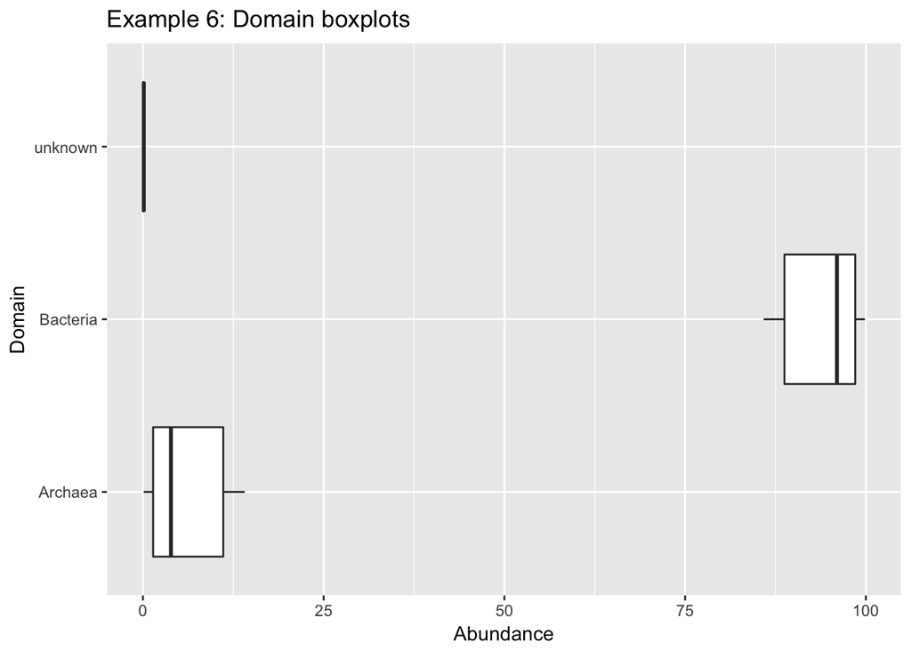

```r
m.perc %>%
  tax_glom(taxrank = 'Domain') %>%
  psmelt() %>%

ggplot() +
  geom_boxplot(aes(x=Domain, y=Abundance)) +
  coord_flip() +
  labs(title="Example 6: Domain boxplots")
```

### Does your taxon of interest *significantly* differ in abundance with depth and/or oxygen concentration?

Using the `magrittr` package, we can pipe our `tidyverse` modified data into linear models and other statiscal tests.

Linear model

```r
m.norm %>%
  subset_taxa(Domain=="unknown") %>%
  tax_glom(taxrank = 'Domain') %>%
  psmelt() %>%

  lm(Abundance ~ Depth_m, .) %>%
  summary()
```

```
##
## Call:
## lm(formula = Abundance ~ Depth_m, data = .)
##
## Residuals:
##       4       3       5       6       2       7       1
##   74.73   56.55   28.92   18.11  -25.03 -106.13  -47.15
##
## Coefficients:
##             Estimate Std. Error t value Pr(>|t|)
## (Intercept)  47.9378    64.5944   0.742    0.491
## Depth_m       0.3209     0.4696   0.683    0.525
##
## Residual standard error: 69.37 on 5 degrees of freedom
## Multiple R-squared:  0.08544,    Adjusted R-squared:  -0.09747
## F-statistic: 0.4671 on 1 and 5 DF,  p-value: 0.5247
```

Plot to go along with linear model above.

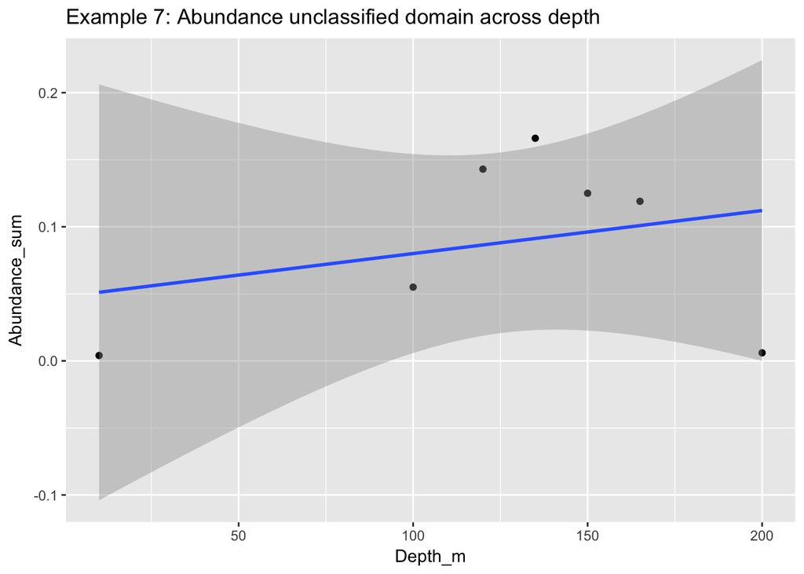

```r
m.perc %>%
  subset_taxa(Domain=="unknown") %>%
  psmelt() %>%
  group_by(Sample) %>%
  summarize(Abundance_sum=sum(Abundance), Depth_m=mean(Depth_m)) %>%

ggplot() +
  geom_point(aes(x=Depth_m, y=Abundance_sum)) +
  geom_smooth(method='lm', aes(x=as.numeric(Depth_m), y=Abundance_sum)) +
  labs(title="Example 7: Abundance unclassified domain across depth")
```

**What about with respect to oxygen?**

### Within your taxon, what is the richness (number of OTUs/ASVs)?

Across all samples, there are 44 OTUs (*i.e.* taxa) within the unclassified domain.

```r
m.norm %>%
  subset_taxa(Domain=="unknown")
```

```
## phyloseq-class experiment-level object
## otu_table()   OTU Table:         [ 44 taxa and 7 samples ]
## sample_data() Sample Data:       [ 7 samples by 22 sample variables ]
## tax_table()   Taxonomy Table:    [ 44 taxa by 7 taxonomic ranks ]
```

Counting OTUs within the unclassified domain within each sample…

```r
m.norm %>%
  subset_taxa(Domain=="unknown") %>%
  estimate_richness(measures = c("Observed"))
```

|  | Observed |
| --- | --- |
| Saanich_010 | 1 |
| Saanich_100 | 10 |
| Saanich_120 | 22 |
| Saanich_135 | 19 |
| Saanich_150 | 19 |
| Saanich_165 | 6 |
| Saanich_200 | 4 |

### Do the abundances of OTUs/ASVs within your taxon of interest change *significantly* with depth and/or oxygen concentration?

General linear model for each OTU  
OTU0242

```r
m.norm %>%
  psmelt() %>%
  filter(OTU=="Otu0242") %>%

  lm(Abundance ~ Depth_m, .) %>%
  summary()
```

```
##
## Call:
## lm(formula = Abundance ~ Depth_m, data = .)
##
## Residuals:
##       1       2       3       4       5       6       7
##  43.142   8.543   3.743 -16.058 -12.056 -25.060  -2.253
##
## Coefficients:
##             Estimate Std. Error t value Pr(>|t|)
## (Intercept)   1.0530    22.7501   0.046    0.965
## Depth_m       0.1200     0.1654   0.726    0.501
##
## Residual standard error: 24.43 on 5 degrees of freedom
## Multiple R-squared:  0.09531,    Adjusted R-squared:  -0.08563
## F-statistic: 0.5267 on 1 and 5 DF,  p-value: 0.5005
```

**Repeat for all OTUs within domain and then correct for multiple comparisons.**

This is all made up p-values.

```r
p.adjust(c(0.501, 0.031, 0.005, 0.324), method="fdr")
```

```
## [1] 0.501 0.062 0.020 0.432
```

Plots to go along with these tests.

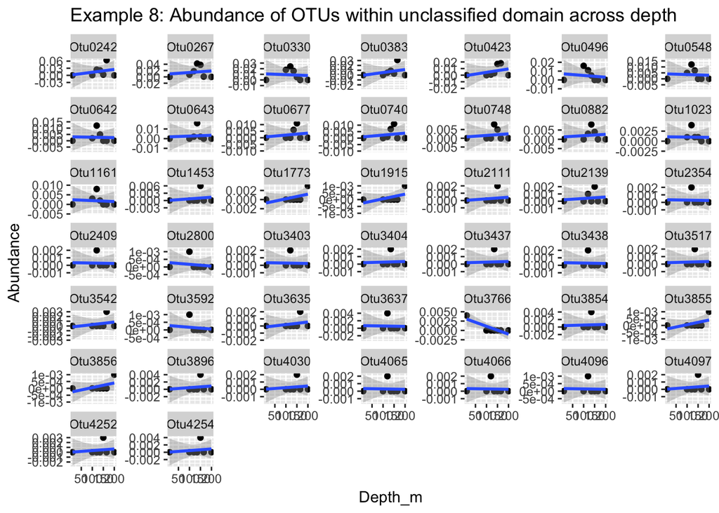

```r
m.perc %>%
  subset_taxa(Domain=="unknown") %>%
  psmelt() %>%

ggplot() +
  geom_point(aes(x=Depth_m, y=Abundance)) +
  geom_smooth(method='lm', aes(x=Depth_m, y=Abundance)) +
  facet_wrap(~OTU, scales="free_y") +
  labs(title="Example 8: Abundance of OTUs within unclassified domain across depth")
```

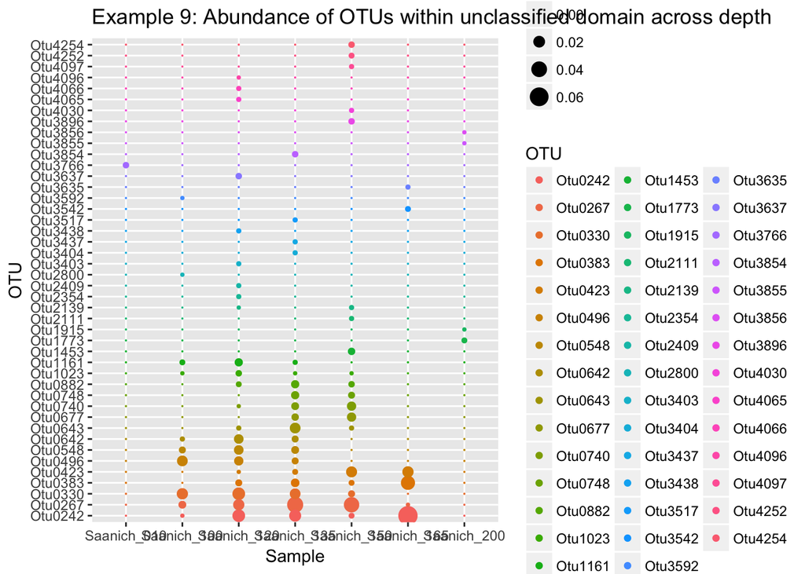

```r
m.perc %>%
  subset_taxa(Domain=="unknown") %>%
  psmelt() %>%

ggplot() +
  geom_point(aes(x=Sample, y=OTU, size=Abundance, color=OTU)) +
  scale_size_continuous(range = c(0,5)) +
  labs(title="Example 9: Abundance of OTUs within unclassified domain across depth")
```

**What about with respect to oxygen?**

**What about QIIME2 ASV data?**

# Discussion

Are the answers to the above the same using mothur and QIIME2 processed data? What are the implications of potential differences in pipelines for microbial ecology research and discovery?

# References

1. Torres-Beltrán M, Hawley AK, Capelle D, Zaikova E, Walsh DA, Mueller A, Scofield M, Payne C, Pakhomova L, Kheirandish S, Finke J, Bhatia M, Shevchuk O, Gies EA, Fairley D, Michiels C, Suttle CA, Whitney F, Crowe SA, Tortell PD, Hallam SJ. 2017. A compendium of geochemical information from the Saanich Inlet water column. Sci Data 4:170159.
2. Hawley AK, Torres-Beltrán M, Zaikova E, Walsh DA, Mueller A, Scofield M, Kheirandish S, Payne C, Pakhomova L, Bhatia M, Shevchuk O, Gies EA, Fairley D, Malfatti SA, Norbeck AD, Brewer HM, Pasa-Tolic L, del Rio TG, Suttle CA, Tringe S, Hallam SJ. 2017. A compendium of multi-omic sequence information from the Saanich Inlet water column. Sci Data 4:170160.
3. Schloss PD, Westcott SL, Ryabin T, Hall JR, Hartmann M, Hollister EB, Lesniewski RA, Oakley BB, Parks DH, Robinson CJ, Sahl JW, Stres B, Thallinger GG, Van Horn DJ, Weber CF, Westcott SL, Ryabin T, Hall JR, Hartmann M, Hollister EB, Lesniewski RA, Oakley BB, Parks DH, Robinson CJ, Sahl JW, Stres B, Thallinger GG, Van Horn DJ, Weber CF. 2009. Introducing mothur: open-source, platform-Independent, community-supported software for describing and comparing microbial communities. Appl Environ Microbiol 75:7537-7541.
4. Caporaso JG, Kuczynski J, Stombaugh J, Bittinger K, Bushman FD, Costello EK, Fierer N, Peña AG, Goodrich JK, Gordon JI, Huttley GA, Kelley ST, Knights D, Koenig JE, Ley RE, Lozupone CA, McDonald D, Muegge BD, Pirrung M, Reeder J, Sevinsky JR, Turnbaugh PJ, Walters WA, Widmann J, Yatsunenko T, Zaneveld J, Knight R. 2010. QIIME allows analysis of high-throughput community sequencing data. Nat Methods 7:335-336.
5. R Core Team. 2017. R: A language and environment for statistical computing. 3.4.3. R Foundation for Statistical Computing, Vienna, Austria.

[figure not shown]

```r
ggplot(m.meta.alpha) +
geom_point(aes(x=as.factor(O2_uM), y=Shannon, color=as.factor(Depth_m), size=3))+
scale_x_discrete(limits=c(20.446, 216.667, 0.000, 38.012, 32.354))
```

# Notes after initial report checks

Figures

- Smoothers (*i.e.* geom_smooth) are not statistics equivalent to linear models. They are merely meant to help visualize the data. And if the smoother doesn’t show a trend you want to then test, you don’t necessary need to include it.
- Figures should have a title and full text legend below the figure, similar to how you would see in a published paper, not just a title and the “legend” that ggplot makes for color, size, etc. This means you will not need to use `labs(title = )`
- If you are having difficulty using a continuous variable as color and seeing any patterns, consider log transforming it and using that as the color variable.
- You do not always need to show *all* the data. Consider only showing the significant OTUs/ASVs in figures. Think about the journal articles you have read and how they use figures to support conclusions, not to just show all the data.
- Note the labels of axes, legends, etc. The defauly ggplot ones are not usually the best.

Results and discussion

- Conclusions should be supported by a p-value (if available) not a plot alone. The plot is just a visual tool, not statistics.
- P-values should be reported in the text or in a table. It is not sufficient to only state that a group of them were < 0.05.

Other

- mothur is all lowercase. QIIME is all uppercase since it is an acronym.
- If you provide your report as an .Rmd, then the code does not *have* to be present in the knit document (though it can be). However, if you provide a Word/PDF document only, the code must be included so that it can be assessed. Within the report as a supplemental file totally okay.

## Multi-panel figures

Of interest to several groups may be how to make multi-panel figures. We can do this easily with the `cowplot` package.

```r
library(cowplot)
```

For example, we will make a multi-panel figure of alpha-diversity and oxygen across depths in the mothur data. First, we create the plots and save them as named objects “plot1” and “plot2”

```r
plot1 = m.meta.alpha %>%

ggplot(aes(x=Depth_m, y=Shannon)) +
  geom_point() +
  geom_line() +
  labs(y="Shannon's diversity index", x="Depth (m)")
```

```r
plot2 = m.meta.alpha %>%

ggplot(aes(x=O2_uM, y=Shannon)) +
  geom_point() +
  geom_line() +
  labs(y="Shannon's diversity index", x="Oxygen (uM)")
```

Then we can plot these two plots together and give A, B, etc labels with `plot_grid`

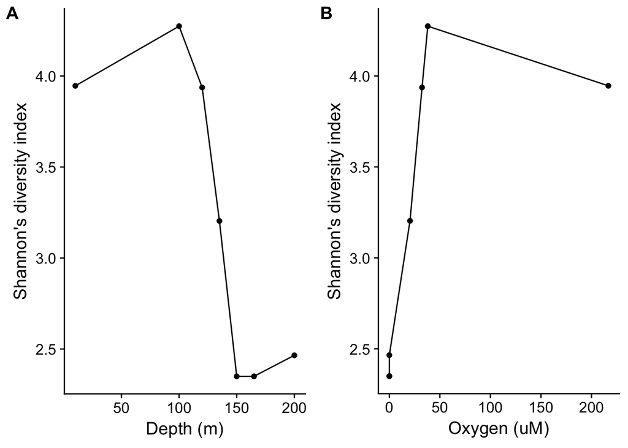

```r
plot_grid(plot1, plot2, labels=c("A", "B"))
```

And we can change the orientation with the number of columns (ncol) or rows (nrow). Or change the relative widths or heights of plots (rel_widths, rel_heights).

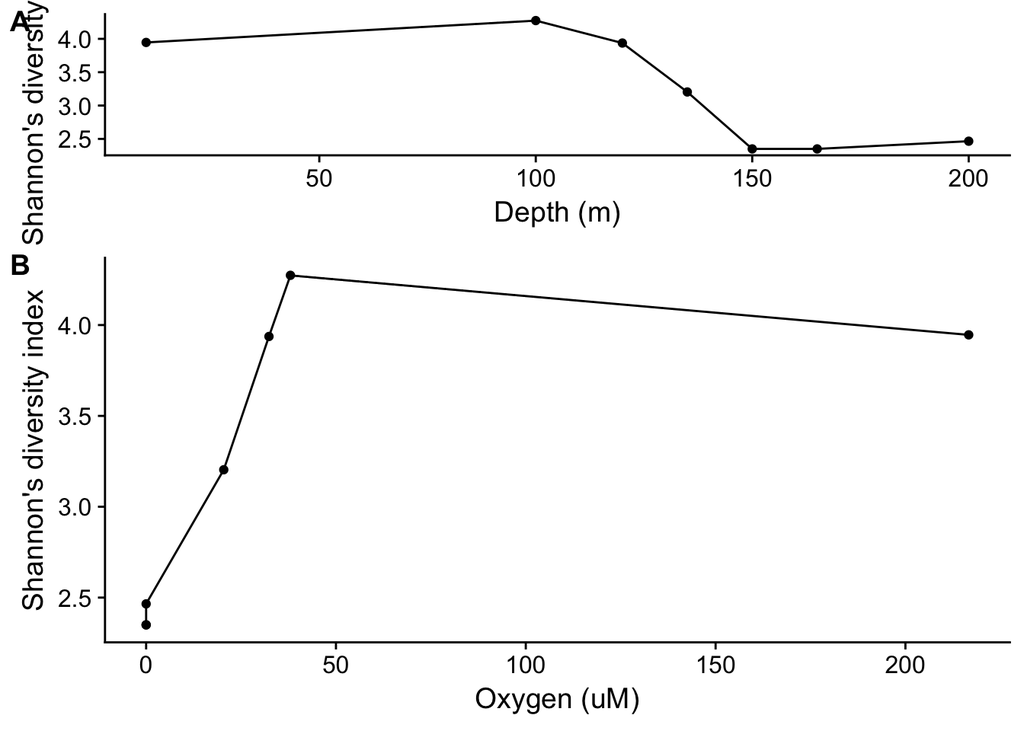

```r
plot_grid(plot1, plot2, labels=c("A", "B"), ncol=1, rel_heights = c(0.5,1))
```

Though this doesn’t really make sense for the plots above. Just an example!

## Figure size

It may also be useful to decrease figure sizes. You can do so by modifying a code chunk as in the following; size is given in inches.

`` ```{r fig.height=3, fig.width=3} ``

`` ``` ``